# PART A: To build a classifier which can use the given parameters to determine the signal strength or quality.

## 1. Data import and Understanding [10 Marks]

### A. Read the ‘Signals.csv’ as DataFrame and import required libraries. [2 Marks]

```python
import pandas as pd
import numpy as np
from sklearn.model_selection import train_test_split
from sklearn.preprocessing import LabelEncoder, OneHotEncoder
from sklearn import model_selection
from sklearn.compose import ColumnTransformer
import matplotlib.pyplot as plt
import seaborn as sns
from sklearn.impute import SimpleImputer
from sklearn import preprocessing
import warnings
from sklearn.metrics import confusion_matrix
from sklearn.pipeline import Pipeline
from sklearn.model_selection import GridSearchCV
from sklearn.model_selection import RandomizedSearchCV
import tensorflow as tf
from tensorflow.keras import backend, optimizers
from tensorflow.keras.models import Sequential
from tensorflow.keras.layers import Dense, Flatten
from tensorflow.keras.layers import Dense, Input, Dropout,BatchNormalization
from tensorflow.keras.wrappers.scikit_learn import KerasClassifier
import random
```

```python
signal = pd.read_csv('signals.csv')
```

```python
signal.head()
```

|  | Parameter 1 | Parameter 2 | Parameter 3 | Parameter 4 | Parameter 5 | Parameter 6 | Parameter 7 | Parameter 8 | Parameter 9 | Parameter 10 | Parameter 11 | Signal_Strength |
| --- | --- | --- | --- | --- | --- | --- | --- | --- | --- | --- | --- | --- |
| 0 | 7.4 | 0.70 | 0.00 | 1.9 | 0.076 | 11.0 | 34.0 | 0.9978 | 3.51 | 0.56 | 9.4 | 5 |
| 1 | 7.8 | 0.88 | 0.00 | 2.6 | 0.098 | 25.0 | 67.0 | 0.9968 | 3.20 | 0.68 | 9.8 | 5 |
| 2 | 7.8 | 0.76 | 0.04 | 2.3 | 0.092 | 15.0 | 54.0 | 0.9970 | 3.26 | 0.65 | 9.8 | 5 |
| 3 | 11.2 | 0.28 | 0.56 | 1.9 | 0.075 | 17.0 | 60.0 | 0.9980 | 3.16 | 0.58 | 9.8 | 6 |
| 4 | 7.4 | 0.70 | 0.00 | 1.9 | 0.076 | 11.0 | 34.0 | 0.9978 | 3.51 | 0.56 | 9.4 | 5 |

```python
signal.count()
```

```
Parameter 1        1599
Parameter 2        1599
Parameter 3        1599
Parameter 4        1599
Parameter 5        1599
Parameter 6        1599
Parameter 7        1599
Parameter 8        1599
Parameter 9        1599
Parameter 10       1599
Parameter 11       1599
Signal_Strength    1599
dtype: int64
```

```python
signal.dtypes
```

```
Parameter 1        float64
Parameter 2        float64
Parameter 3        float64
Parameter 4        float64
Parameter 5        float64
Parameter 6        float64
Parameter 7        float64
Parameter 8        float64
Parameter 9        float64
Parameter 10       float64
Parameter 11       float64
Signal_Strength      int64
dtype: object
```

```python
signal.info()
```

```
<class 'pandas.core.frame.DataFrame'>
RangeIndex: 1599 entries, 0 to 1598
Data columns (total 12 columns):
 #   Column           Non-Null Count  Dtype
---  ------           --------------  -----
 0   Parameter 1      1599 non-null   float64
 1   Parameter 2      1599 non-null   float64
 2   Parameter 3      1599 non-null   float64
 3   Parameter 4      1599 non-null   float64
 4   Parameter 5      1599 non-null   float64
 5   Parameter 6      1599 non-null   float64
 6   Parameter 7      1599 non-null   float64
 7   Parameter 8      1599 non-null   float64
 8   Parameter 9      1599 non-null   float64
 9   Parameter 10     1599 non-null   float64
 10  Parameter 11     1599 non-null   float64
 11  Signal_Strength  1599 non-null   int64
dtypes: float64(11), int64(1)
memory usage: 150.0 KB
```

```python
signal.describe()
```

|  | Parameter 1 | Parameter 2 | Parameter 3 | Parameter 4 | Parameter 5 | Parameter 6 | Parameter 7 | Parameter 8 | Parameter 9 | Parameter 10 | Parameter 11 | Signal_Strength |
| --- | --- | --- | --- | --- | --- | --- | --- | --- | --- | --- | --- | --- |
| count | 1599.000000 | 1599.000000 | 1599.000000 | 1599.000000 | 1599.000000 | 1599.000000 | 1599.000000 | 1599.000000 | 1599.000000 | 1599.000000 | 1599.000000 | 1599.000000 |
| mean | 8.319637 | 0.527821 | 0.270976 | 2.538806 | 0.087467 | 15.874922 | 46.467792 | 0.996747 | 3.311113 | 0.658149 | 10.422983 | 5.636023 |
| std | 1.741096 | 0.179060 | 0.194801 | 1.409928 | 0.047065 | 10.460157 | 32.895324 | 0.001887 | 0.154386 | 0.169507 | 1.065668 | 0.807569 |
| min | 4.600000 | 0.120000 | 0.000000 | 0.900000 | 0.012000 | 1.000000 | 6.000000 | 0.990070 | 2.740000 | 0.330000 | 8.400000 | 3.000000 |
| 25% | 7.100000 | 0.390000 | 0.090000 | 1.900000 | 0.070000 | 7.000000 | 22.000000 | 0.995600 | 3.210000 | 0.550000 | 9.500000 | 5.000000 |
| 50% | 7.900000 | 0.520000 | 0.260000 | 2.200000 | 0.079000 | 14.000000 | 38.000000 | 0.996750 | 3.310000 | 0.620000 | 10.200000 | 6.000000 |
| 75% | 9.200000 | 0.640000 | 0.420000 | 2.600000 | 0.090000 | 21.000000 | 62.000000 | 0.997835 | 3.400000 | 0.730000 | 11.100000 | 6.000000 |
| max | 15.900000 | 1.580000 | 1.000000 | 15.500000 | 0.611000 | 72.000000 | 289.000000 | 1.003690 | 4.010000 | 2.000000 | 14.900000 | 8.000000 |

### B. Check for missing values and print percentage for each attribute. [2 Marks]

```python
# Quick check on null values
for cols in signal.columns:
    print("Number of null values for {0} cols is {1}".format(cols,signal[cols].isnull().sum()))
```

```
Number of null values for Parameter 1 cols is 0
Number of null values for Parameter 2 cols is 0
Number of null values for Parameter 3 cols is 0
Number of null values for Parameter 4 cols is 0
Number of null values for Parameter 5 cols is 0
Number of null values for Parameter 6 cols is 0
Number of null values for Parameter 7 cols is 0
Number of null values for Parameter 8 cols is 0
Number of null values for Parameter 9 cols is 0
Number of null values for Parameter 10 cols is 0
Number of null values for Parameter 11 cols is 0
Number of null values for Signal_Strength cols is 0
```

```python
# feature-wise percentage of missing values present in the data
def find_missing(df):
    null_percentage=[{col : df[col].isnull().sum()*100/len(df)} for col in df.columns]
    for x in null_percentage:
        for k,v in x.items():
            print("Column name: {0} ; missing percentage : {1}".format(k,v))
```

```python
find_missing(signal)
```

```
Column name: Parameter 1 ; missing percentage : 0.0
Column name: Parameter 2 ; missing percentage : 0.0
Column name: Parameter 3 ; missing percentage : 0.0
Column name: Parameter 4 ; missing percentage : 0.0
Column name: Parameter 5 ; missing percentage : 0.0
Column name: Parameter 6 ; missing percentage : 0.0
Column name: Parameter 7 ; missing percentage : 0.0
Column name: Parameter 8 ; missing percentage : 0.0
Column name: Parameter 9 ; missing percentage : 0.0
Column name: Parameter 10 ; missing percentage : 0.0
Column name: Parameter 11 ; missing percentage : 0.0
Column name: Signal_Strength ; missing percentage : 0.0
```

##### Insights: There are no null values in any signal dataframe columns. All columns show 0 precentage for missing value. No imputation needed for missing values.

### C. Check for presence of duplicate records in the dataset and impute with appropriate method. [2 Marks]

```python
# Finding duplicate values
def get_value_counts(df):
    for cols in df.columns:
        print("\nUnique values and its counts for {}".format(cols))
        print(df[cols].value_counts())
        print("\n*********************************************")
```

```python
get_value_counts(signal)
```

[output not shown]

[output cut: 167 more lines]

```
9.233333       1
9.250000       1
9.050000       1
10.750000      1
Name: Parameter 11, Length: 65, dtype: int64


Unique values and its counts for Signal_Strength
5    681
6    638
7    199
4     53
8     18
3     10
Name: Signal_Strength, dtype: int64
```

```python
print(signal.duplicated().sum())
```

```
240
```

#### Insights:

- signal dataframe has 240 duplicates. The duplicates can be removed in order to avoid overfitting.

```python
signal = signal.drop(signal[signal.duplicated()].index,axis = 0).reset_index(drop = True)
print('Number of duplicate values rows after clean up : ',signal.duplicated().sum())
```

```
Number of duplicate values rows after clean up :  0
```

```python
signal.shape
```

```
(1359, 12)
```

### D. Visualise distribution of the target variable. [2 Marks]

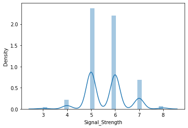

```python
sns.distplot(signal['Signal_Strength'])
```

```python
signal_counts=signal['Signal_Strength'].value_counts()
signal_df = pd.DataFrame(signal_counts)
signal_df = signal_df.reset_index()
signal_df.columns = ['signal_vals', 'signal_cnt']
signal_df.head(10)
```

|  | signal_vals | signal_cnt |
| --- | --- | --- |
| 0 | 5 | 577 |
| 1 | 6 | 535 |
| 2 | 7 | 167 |
| 3 | 4 | 53 |
| 4 | 8 | 17 |
| 5 | 3 | 10 |

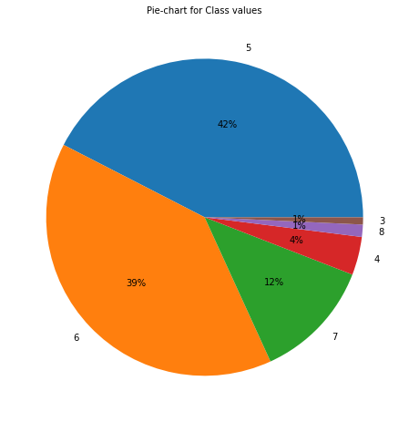

```python
plt.figure(figsize=(8,8))
plt.pie(data=signal_df, labels='signal_vals',x='signal_cnt',autopct='%.0f%%')
plt.title("Pie-chart for Class values", size=10)
plt.show()
```

### E. Share insights from the initial data analysis (at least 2). [2 Marks]

- The signal dataset covers only singal strength of 3,4,5,6,7,8. There is norecord for signal strengths 0,1,2,9.
- Also there is a very less representaion for classes 3 & 8 (~1%)
- Signal strength of 5 covers almost half of the population i.e ~42%, followed by signal strength of 6 with 39%

```python
# Few more exploration of signal data
print(signal.describe())
```

```
       Parameter 1  Parameter 2  Parameter 3  Parameter 4  Parameter 5  \
count  1359.000000  1359.000000  1359.000000  1359.000000  1359.000000
mean      8.310596     0.529478     0.272333     2.523400     0.088124
std       1.736990     0.183031     0.195537     1.352314     0.049377
min       4.600000     0.120000     0.000000     0.900000     0.012000
25%       7.100000     0.390000     0.090000     1.900000     0.070000
50%       7.900000     0.520000     0.260000     2.200000     0.079000
75%       9.200000     0.640000     0.430000     2.600000     0.091000
max      15.900000     1.580000     1.000000    15.500000     0.611000

       Parameter 6  Parameter 7  Parameter 8  Parameter 9  Parameter 10  \
count  1359.000000  1359.000000  1359.000000  1359.000000   1359.000000
mean     15.893304    46.825975     0.996709     3.309787      0.658705
std      10.447270    33.408946     0.001869     0.155036      0.170667
min       1.000000     6.000000     0.990070     2.740000      0.330000
25%       7.000000    22.000000     0.995600     3.210000      0.550000
50%      14.000000    38.000000     0.996700     3.310000      0.620000
75%      21.000000    63.000000     0.997820     3.400000      0.730000
max      72.000000   289.000000     1.003690     4.010000      2.000000

       Parameter 11  Signal_Strength
count   1359.000000      1359.000000
mean      10.432315         5.623252
std        1.082065         0.823578
min        8.400000         3.000000
25%        9.500000         5.000000
50%       10.200000         6.000000
75%       11.100000         6.000000
max       14.900000         8.000000
```

- Few parameters have value ranges as low as 0 to 1 whereas few parameters have value ranges ~46 to ~289.
- Due to various value ranges in the data, we need to normalize the data before feeding to model. This is taken care in 2 D.

```python
# Exploring the data for a random signal strength say 6
print(signal[signal['Signal_Strength'] == 6].mean())
```

```
Parameter 1         8.337383
Parameter 2         0.496084
Parameter 3         0.279364
Parameter 4         2.457290
Parameter 5         0.085075
Parameter 6        15.637383
Parameter 7        40.816822
Parameter 8         0.996565
Parameter 9         3.318000
Parameter 10        0.674542
Parameter 11       10.658879
Signal_Strength     6.000000
dtype: float64
```

```python
# Coorelation matrix
corr_matrix = signal.corr()
print(corr_matrix["Signal_Strength"].sort_values(ascending=False))
```

```
Signal_Strength    1.000000
Parameter 11       0.480343
Parameter 10       0.248835
Parameter 3        0.228057
Parameter 1        0.119024
Parameter 4        0.013640
Parameter 6       -0.050463
Parameter 9       -0.055245
Parameter 5       -0.130988
Parameter 7       -0.177855
Parameter 8       -0.184252
Parameter 2       -0.395214
Name: Signal_Strength, dtype: float64
```

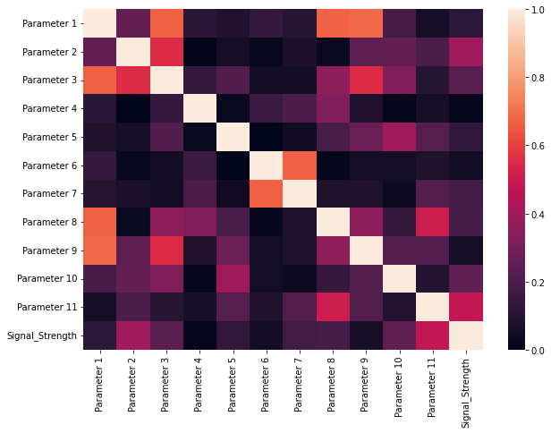

```python
plt.figure(figsize = (10,7))
sns.heatmap(abs(signal.corr()), vmin = 0, vmax = 1)
plt.show()
```

- Half of the parameters have positive correlation and other half of the parameters have negative correlation.

## 2. Data preprocessing [7 Marks]

### A. Split the data into X & Y. [1 Marks]

```python
X=signal.drop(columns=['Signal_Strength'],axis=1)
y=signal[['Signal_Strength']]
X.describe()
```

|  | Parameter 1 | Parameter 2 | Parameter 3 | Parameter 4 | Parameter 5 | Parameter 6 | Parameter 7 | Parameter 8 | Parameter 9 | Parameter 10 | Parameter 11 |
| --- | --- | --- | --- | --- | --- | --- | --- | --- | --- | --- | --- |
| count | 1359.000000 | 1359.000000 | 1359.000000 | 1359.000000 | 1359.000000 | 1359.000000 | 1359.000000 | 1359.000000 | 1359.000000 | 1359.000000 | 1359.000000 |
| mean | 8.310596 | 0.529478 | 0.272333 | 2.523400 | 0.088124 | 15.893304 | 46.825975 | 0.996709 | 3.309787 | 0.658705 | 10.432315 |
| std | 1.736990 | 0.183031 | 0.195537 | 1.352314 | 0.049377 | 10.447270 | 33.408946 | 0.001869 | 0.155036 | 0.170667 | 1.082065 |
| min | 4.600000 | 0.120000 | 0.000000 | 0.900000 | 0.012000 | 1.000000 | 6.000000 | 0.990070 | 2.740000 | 0.330000 | 8.400000 |
| 25% | 7.100000 | 0.390000 | 0.090000 | 1.900000 | 0.070000 | 7.000000 | 22.000000 | 0.995600 | 3.210000 | 0.550000 | 9.500000 |
| 50% | 7.900000 | 0.520000 | 0.260000 | 2.200000 | 0.079000 | 14.000000 | 38.000000 | 0.996700 | 3.310000 | 0.620000 | 10.200000 |
| 75% | 9.200000 | 0.640000 | 0.430000 | 2.600000 | 0.091000 | 21.000000 | 63.000000 | 0.997820 | 3.400000 | 0.730000 | 11.100000 |
| max | 15.900000 | 1.580000 | 1.000000 | 15.500000 | 0.611000 | 72.000000 | 289.000000 | 1.003690 | 4.010000 | 2.000000 | 14.900000 |

```python
X.shape
```

```
(1359, 11)
```

```python
X.info()
```

```
<class 'pandas.core.frame.DataFrame'>
RangeIndex: 1359 entries, 0 to 1358
Data columns (total 11 columns):
 #   Column        Non-Null Count  Dtype
---  ------        --------------  -----
 0   Parameter 1   1359 non-null   float64
 1   Parameter 2   1359 non-null   float64
 2   Parameter 3   1359 non-null   float64
 3   Parameter 4   1359 non-null   float64
 4   Parameter 5   1359 non-null   float64
 5   Parameter 6   1359 non-null   float64
 6   Parameter 7   1359 non-null   float64
 7   Parameter 8   1359 non-null   float64
 8   Parameter 9   1359 non-null   float64
 9   Parameter 10  1359 non-null   float64
 10  Parameter 11  1359 non-null   float64
dtypes: float64(11)
memory usage: 116.9 KB
```

```python
y.describe()
```

|  | Signal_Strength |
| --- | --- |
| count | 1359.000000 |
| mean | 5.623252 |
| std | 0.823578 |
| min | 3.000000 |
| 25% | 5.000000 |
| 50% | 6.000000 |
| 75% | 6.000000 |
| max | 8.000000 |

```python
y.shape
```

```
(1359, 1)
```

```python
y.info()
```

```
<class 'pandas.core.frame.DataFrame'>
RangeIndex: 1359 entries, 0 to 1358
Data columns (total 1 columns):
 #   Column           Non-Null Count  Dtype
---  ------           --------------  -----
 0   Signal_Strength  1359 non-null   int64
dtypes: int64(1)
memory usage: 10.7 KB
```

### B. Split the data into train & test with 70:30 proportion.[1 Marks]

```python
X_train,X_test,y_train,y_test=train_test_split(X,y,test_size=0.30,random_state=1)
X_train
```

|  | Parameter 1 | Parameter 2 | Parameter 3 | Parameter 4 | Parameter 5 | Parameter 6 | Parameter 7 | Parameter 8 | Parameter 9 | Parameter 10 | Parameter 11 |
| --- | --- | --- | --- | --- | --- | --- | --- | --- | --- | --- | --- |
| 264 | 7.4 | 0.670 | 0.12 | 1.6 | 0.186 | 5.0 | 21.0 | 0.99600 | 3.39 | 0.54 | 9.5 |
| 1101 | 5.9 | 0.395 | 0.13 | 2.4 | 0.056 | 14.0 | 28.0 | 0.99362 | 3.62 | 0.67 | 12.4 |
| 602 | 5.1 | 0.470 | 0.02 | 1.3 | 0.034 | 18.0 | 44.0 | 0.99210 | 3.90 | 0.62 | 12.8 |
| 393 | 8.4 | 0.370 | 0.53 | 1.8 | 0.413 | 9.0 | 26.0 | 0.99790 | 3.06 | 1.06 | 9.1 |
| 1115 | 7.0 | 0.620 | 0.10 | 1.4 | 0.071 | 27.0 | 63.0 | 0.99600 | 3.28 | 0.61 | 9.2 |
| ... | ... | ... | ... | ... | ... | ... | ... | ... | ... | ... | ... |
| 715 | 7.8 | 0.570 | 0.09 | 2.3 | 0.065 | 34.0 | 45.0 | 0.99417 | 3.46 | 0.74 | 12.7 |
| 905 | 10.2 | 0.290 | 0.65 | 2.4 | 0.075 | 6.0 | 17.0 | 0.99565 | 3.22 | 0.63 | 11.8 |
| 1096 | 7.1 | 0.160 | 0.44 | 2.5 | 0.068 | 17.0 | 31.0 | 0.99328 | 3.35 | 0.54 | 12.4 |
| 235 | 7.9 | 0.350 | 0.46 | 3.6 | 0.078 | 15.0 | 37.0 | 0.99730 | 3.35 | 0.86 | 12.8 |
| 1061 | 7.4 | 0.550 | 0.19 | 1.8 | 0.082 | 15.0 | 34.0 | 0.99655 | 3.49 | 0.68 | 10.5 |

951 rows × 11 columns

```python
X_test
```

|  | Parameter 1 | Parameter 2 | Parameter 3 | Parameter 4 | Parameter 5 | Parameter 6 | Parameter 7 | Parameter 8 | Parameter 9 | Parameter 10 | Parameter 11 |
| --- | --- | --- | --- | --- | --- | --- | --- | --- | --- | --- | --- |
| 414 | 9.9 | 0.350 | 0.55 | 2.1 | 0.062 | 5.0 | 14.0 | 0.99710 | 3.26 | 0.79 | 10.6 |
| 1167 | 8.2 | 0.885 | 0.20 | 1.4 | 0.086 | 7.0 | 31.0 | 0.99460 | 3.11 | 0.46 | 10.0 |
| 464 | 10.3 | 0.270 | 0.24 | 2.1 | 0.072 | 15.0 | 33.0 | 0.99560 | 3.22 | 0.66 | 12.8 |
| 177 | 9.6 | 0.320 | 0.47 | 1.4 | 0.056 | 9.0 | 24.0 | 0.99695 | 3.22 | 0.82 | 10.3 |
| 236 | 6.9 | 0.540 | 0.04 | 3.0 | 0.077 | 7.0 | 27.0 | 0.99870 | 3.69 | 0.91 | 9.4 |
| ... | ... | ... | ... | ... | ... | ... | ... | ... | ... | ... | ... |
| 800 | 7.2 | 0.380 | 0.38 | 2.8 | 0.068 | 23.0 | 42.0 | 0.99356 | 3.34 | 0.72 | 12.9 |
| 936 | 7.4 | 0.490 | 0.27 | 2.1 | 0.071 | 14.0 | 25.0 | 0.99388 | 3.35 | 0.63 | 12.0 |
| 1216 | 10.2 | 0.540 | 0.37 | 15.4 | 0.214 | 55.0 | 95.0 | 1.00369 | 3.18 | 0.77 | 9.0 |
| 664 | 7.1 | 0.590 | 0.02 | 2.3 | 0.082 | 24.0 | 94.0 | 0.99744 | 3.55 | 0.53 | 9.7 |
| 612 | 7.4 | 0.490 | 0.19 | 3.0 | 0.077 | 16.0 | 37.0 | 0.99660 | 3.37 | 0.51 | 10.5 |

408 rows × 11 columns

```python
y_train
```

|  | Signal_Strength |
| --- | --- |
| 264 | 5 |
| 1101 | 6 |
| 602 | 6 |
| 393 | 6 |
| 1115 | 5 |
| ... | ... |
| 715 | 8 |
| 905 | 6 |
| 1096 | 6 |
| 235 | 8 |
| 1061 | 5 |

951 rows × 1 columns

```python
y_test
```

|  | Signal_Strength |
| --- | --- |
| 414 | 5 |
| 1167 | 5 |
| 464 | 6 |
| 177 | 7 |
| 236 | 6 |
| ... | ... |
| 800 | 7 |
| 936 | 6 |
| 1216 | 6 |
| 664 | 6 |
| 612 | 5 |

408 rows × 1 columns

### C. Print shape of all the 4 variables and verify if train and test data is in sync. [1 Marks]

```python
print("Shape of X_train :", X_train.shape)
```

```
Shape of X_train : (951, 11)
```

```python
print("Shape of X_test :", X_test.shape)
```

```
Shape of X_test : (408, 11)
```

```python
print("Shape of y_train :", y_train.shape)
```

```
Shape of y_train : (951, 1)
```

```python
print("Shape of y_test :", y_test.shape)
```

```
Shape of y_test : (408, 1)
```

### D. Normalise the train and test data with appropriate method. [2 Marks]

```python
scaler = preprocessing.StandardScaler().fit(X_train)
```

```python
X_train_s = scaler.transform(X_train)
print ("Mean of X_train_s:{} \n".format(X_train_s.mean(axis=0)))
print ("STD of X_train_s:{}".format(X_train_s.std(axis=0)))
```

```
Mean of X_train_s:[-6.45820586e-16 -1.23280285e-16  1.38223350e-16 -4.10934285e-17
 -1.65774626e-16 -4.10934285e-17 -6.53759089e-17  4.82492887e-14
 -3.87212169e-15 -8.49419845e-16  2.76446701e-16]

STD of X_train_s:[1. 1. 1. 1. 1. 1. 1. 1. 1. 1. 1.]
```

```python
X_test_s = scaler.transform(X_test)

print ("Mean of X_test_s:{} \n".format(X_test_s.mean(axis=0)))
print ("STD of X_test_s:{}".format(X_test_s.std(axis=0)))
```

```
Mean of X_test_s:[-0.04342632  0.05955924 -0.03176371 -0.01986657  0.02408524  0.00564715
  0.06871544 -0.01792347  0.04669374  0.06662197 -0.00016705]

STD of X_test_s:[0.95357321 0.94292709 1.00141406 1.0738071  1.05715255 0.96154548
 1.12629794 1.01717766 1.09423028 1.21059219 1.01469354]
```

### E. Transform Labels into format acceptable by Neural Network [2 Marks]

```python
# Converting y data into categorical (one-hot encoding)
from keras.utils.np_utils import to_categorical
y_train_s = to_categorical(y_train)
y_test_s = to_categorical(y_test)
```

```python
y_train_s
```

```
array([[0., 0., 0., ..., 0., 0., 0.],
       [0., 0., 0., ..., 1., 0., 0.],
       [0., 0., 0., ..., 1., 0., 0.],
       ...,
       [0., 0., 0., ..., 1., 0., 0.],
       [0., 0., 0., ..., 0., 0., 1.],
       [0., 0., 0., ..., 0., 0., 0.]], dtype=float32)
```

```python
y_test_s
```

```
array([[0., 0., 0., ..., 0., 0., 0.],
       [0., 0., 0., ..., 0., 0., 0.],
       [0., 0., 0., ..., 1., 0., 0.],
       ...,
       [0., 0., 0., ..., 1., 0., 0.],
       [0., 0., 0., ..., 1., 0., 0.],
       [0., 0., 0., ..., 0., 0., 0.]], dtype=float32)
```

```python
print("Shape of X_train_s : {}".format(X_train_s.shape))
print("Shape of X_test_s  : {}".format(X_test_s.shape))
print("Shape of y_train_s : {}".format(y_train_s.shape))
print("Shape of y_test_s  : {}".format(y_test_s.shape))
```

```
Shape of X_train_s : (951, 11)
Shape of X_test_s  : (408, 11)
Shape of y_train_s : (951, 9)
Shape of y_test_s  : (408, 9)
```

## 3. Model Training & Evaluation using Neural Network [13 Marks]

### A. Design a Neural Network to train a classifier. [3 Marks]

```python
from keras.models import Sequential # Forward prop
from keras.layers import Dense, Activation, LeakyReLU
from keras import optimizers
```

```python
def create_model(lr,batch_size):
    np.random.seed(100)
    nn_classifier_model = Sequential()

    # Input Layer :
    nn_classifier_model.add(Dense(128, kernel_initializer='he_normal',input_dim = X_train_s.shape[1], activation='relu'))

    # Hidden Layers :
    nn_classifier_model.add(Dense(64, kernel_initializer='he_normal'))
    nn_classifier_model.add(LeakyReLU(alpha=0.1))

    nn_classifier_model.add(Dense(32, kernel_initializer='he_normal'))
    nn_classifier_model.add(LeakyReLU(alpha=0.1))

    nn_classifier_model.add(Dense(16, kernel_initializer='he_normal'))
    nn_classifier_model.add(LeakyReLU(alpha=0.1))

    # Output Layer :
    nn_classifier_model.add(Dense(9, kernel_initializer='he_normal',activation='softmax'))

    # Compile :
    optimizer = tf.keras.optimizers.Adam(learning_rate=lr)
    nn_classifier_model.compile(loss='mean_absolute_error', optimizer=optimizer, metrics=['accuracy'])
    nn_classifier_model.summary()
    return nn_classifier_model
```

### B. Train the classifier using previously designed Architecture [2 Marks]

```python
lr=0.01
batch_size=200
EPOCH=400
nn_classifier_model = create_model(lr,batch_size)
first_model = nn_classifier_model.fit(X_train_s, y_train_s, validation_data=(X_test_s,y_test_s),epochs=EPOCH, verbose = 1)
```

```
Model: "sequential"
_________________________________________________________________
 Layer (type)                Output Shape              Param #
=================================================================
 dense (Dense)               (None, 128)               1536

 dense_1 (Dense)             (None, 64)                8256

 leaky_re_lu (LeakyReLU)     (None, 64)                0

 dense_2 (Dense)             (None, 32)                2080

 leaky_re_lu_1 (LeakyReLU)   (None, 32)                0

 dense_3 (Dense)             (None, 16)                528

 leaky_re_lu_2 (LeakyReLU)   (None, 16)                0

 dense_4 (Dense)             (None, 9)                 153

=================================================================
Total params: 12,553
Trainable params: 12,553
Non-trainable params: 0
_________________________________________________________________
```

```python
first_model_results = nn_classifier_model.evaluate(X_test_s, y_test_s)
```

```python
print('Test loss: ', first_model_results[0])
print('Test accuracy: ', first_model_results[1])
```

```
Test loss:  0.10239651799201965
Test accuracy:  0.5392156839370728
```

### C. Plot 2 separate visuals. [3 Marks]

#### i. Plotting training Loss, validation Loss Vs number of epochs

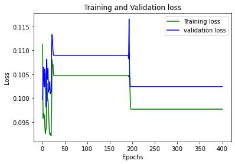

```python
loss_train = first_model.history['loss']
loss_val = first_model.history['val_loss']
epochs = range(1,EPOCH+1)
plt.plot(epochs, loss_train, 'g', label='Training loss')
plt.plot(epochs, loss_val, 'b', label='validation loss')
plt.title('Training and Validation loss')
plt.xlabel('Epochs')
plt.ylabel('Loss')
plt.legend()
plt.show()
```

#### ii. Plotting training accuracy, validation accuracy Vs number of epochs

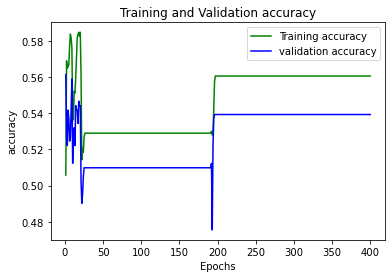

```python
Acc_train = first_model.history['accuracy']
Acc_val = first_model.history['val_accuracy']
epochs = range(1,EPOCH+1)
plt.plot(epochs, Acc_train, 'g', label='Training accuracy')
plt.plot(epochs, Acc_val, 'b', label='validation accuracy')
plt.title('Training and Validation accuracy')
plt.xlabel('Epochs')
plt.ylabel('accuracy')
plt.legend()
plt.show()
```

### D. Design new architecture/update existing architecture in attempt to improve the performance of the model. [2 Marks]

```python
def updated_model(lr,batch_size):
    np.random.seed(100)
    nn_classifier_model1 = Sequential()

    # Input Layer :
    nn_classifier_model1.add(Dense(128, kernel_initializer='he_normal',input_dim = X_train_s.shape[1], activation='relu'))
    nn_classifier_model1.add(Dropout(0.2))

    # Hidden Layers :
    nn_classifier_model1.add(Dense(64, kernel_initializer='he_normal',activation='relu'))
    nn_classifier_model1.add(Dropout(0.2))

    nn_classifier_model1.add(Dense(32, kernel_initializer='he_normal',activation='relu'))
    nn_classifier_model1.add(Dropout(0.2))

    nn_classifier_model1.add(Dense(16, kernel_initializer='he_normal',activation='relu'))
    nn_classifier_model1.add(Dropout(0.2))


    # Output Layer :
    nn_classifier_model1.add(Dense(9, kernel_initializer='he_normal',activation='softmax'))

    # Compile :
    optimizer = tf.keras.optimizers.Adam(learning_rate=lr)
    nn_classifier_model1.compile(loss='categorical_crossentropy', optimizer=optimizer, metrics=['accuracy'])
    nn_classifier_model1.summary()
    return nn_classifier_model1
```

```python
import warnings
warnings.filterwarnings('ignore')
keras_estimator = KerasClassifier(build_fn=updated_model, verbose=1)
# Grid search parameters
param_grid = {
    "batch_size":[100,200],
    "lr":[0.001,0.01],
    "epochs":[100,200,400]
}

kfold_splits = 3
grid = GridSearchCV(estimator=keras_estimator,
                    verbose=1,
                    cv=kfold_splits,
                    param_grid=param_grid,n_jobs=-1)
```

```python
grid_result = grid.fit(X_train_s, y_train_s,validation_data=(X_test_s,y_test_s),verbose=1)

print("Best: %f using %s" % (grid_result.best_score_, grid_result.best_params_))
means = grid_result.cv_results_['mean_test_score']
stds = grid_result.cv_results_['std_test_score']
params = grid_result.cv_results_['params']
```

```
Fitting 3 folds for each of 12 candidates, totalling 36 fits
Model: "sequential_1"
_________________________________________________________________
 Layer (type)                Output Shape              Param #
=================================================================
 dense_5 (Dense)             (None, 128)               1536

 dropout (Dropout)           (None, 128)               0

 dense_6 (Dense)             (None, 64)                8256

 dropout_1 (Dropout)         (None, 64)                0

 dense_7 (Dense)             (None, 32)                2080

 dropout_2 (Dropout)         (None, 32)                0

 dense_8 (Dense)             (None, 16)                528

 dropout_3 (Dropout)         (None, 16)                0

 dense_9 (Dense)             (None, 9)                 153

=================================================================
Total params: 12,553
Trainable params: 12,553
Non-trainable params: 0
_________________________________________________________________
Best: 0.607781 using {'batch_size': 100, 'epochs': 100, 'lr': 0.001}
```

```python
nn_classifier_model_tuned=updated_model(lr=grid_result.best_params_['lr'],batch_size=grid_result.best_params_['batch_size'])
nn_classifier_model_tuned.summary()
```

```
Model: "sequential_2"
_________________________________________________________________
 Layer (type)                Output Shape              Param #
=================================================================
 dense_10 (Dense)            (None, 128)               1536

 dropout_4 (Dropout)         (None, 128)               0

 dense_11 (Dense)            (None, 64)                8256

 dropout_5 (Dropout)         (None, 64)                0

 dense_12 (Dense)            (None, 32)                2080

 dropout_6 (Dropout)         (None, 32)                0

 dense_13 (Dense)            (None, 16)                528

 dropout_7 (Dropout)         (None, 16)                0

 dense_14 (Dense)            (None, 9)                 153

=================================================================
Total params: 12,553
Trainable params: 12,553
Non-trainable params: 0
_________________________________________________________________
Model: "sequential_2"
_________________________________________________________________
 Layer (type)                Output Shape              Param #
=================================================================
 dense_10 (Dense)            (None, 128)               1536

 dropout_4 (Dropout)         (None, 128)               0

 dense_11 (Dense)            (None, 64)                8256

 dropout_5 (Dropout)         (None, 64)                0

 dense_12 (Dense)            (None, 32)                2080

 dropout_6 (Dropout)         (None, 32)                0

 dense_13 (Dense)            (None, 16)                528

 dropout_7 (Dropout)         (None, 16)                0

 dense_14 (Dense)            (None, 9)                 153

=================================================================
Total params: 12,553
Trainable params: 12,553
Non-trainable params: 0
_________________________________________________________________
```

```python
final_model=nn_classifier_model_tuned.fit(X_train_s, y_train_s, epochs=grid_result.best_params_['epochs'], verbose=1,validation_data=(X_test_s,y_test_s))
```

```python
final_model_results = nn_classifier_model_tuned.evaluate(X_test_s, y_test_s)
```

```python
print("The best parameters are as below: \nLearning Rate: {0} \nBatch size: {1} \nEpochs :{2}".format(grid_result.best_params_['lr'],grid_result.best_params_['batch_size'],grid_result.best_params_['epochs']))
```

```
The best parameters are as below:
Learning Rate: 0.001
Batch size: 100
Epochs :100
```

### E. Plot visuals as in Q3.C and share insights about difference observed in both the models. [3 Marks]

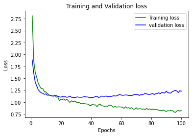

```python
EPOCH=grid_result.best_params_['epochs']
loss_train = final_model.history['loss']
loss_val = final_model.history['val_loss']
epochs = range(1,EPOCH+1)
plt.plot(epochs, loss_train, 'g', label='Training loss')
plt.plot(epochs, loss_val, 'b', label='validation loss')
plt.title('Training and Validation loss')
plt.xlabel('Epochs')
plt.ylabel('Loss')
plt.legend()
plt.show()
```

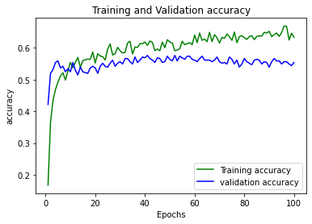

```python
Acc_train = final_model.history['accuracy']
Acc_val = final_model.history['val_accuracy']
epochs = range(1,EPOCH+1)
plt.plot(epochs, Acc_train, 'g', label='Training accuracy')
plt.plot(epochs, Acc_val, 'b', label='validation accuracy')
plt.title('Training and Validation accuracy')
plt.xlabel('Epochs')
plt.ylabel('accuracy')
plt.legend()
plt.show()
```

#### Observation:

Neural Network classifier model with 1 input layer, 3 hidden layers and 1 output layer was built using relu activation function.

With the best suitable parameters of Learning Rate: 0.001, Batch size: 100 , Epochs :100 the NN classifier model gave the below results:

- Accuracy in training dataset = 63.30%
- Accuracy in test dataset = 55.39%

#### Conclusion: Model Training accuracy of 63.30% and Test accuracy of 55.39% is the optimized model that was built for this signals dataset.

# PART B: To build a digit classifier on the SVHN (Street View Housing Number) dataset.

## Steps and tasks: [ Total Score: 30 Marks]

## 1. Data Import and Exploration [5 Marks]

### A. Read the .h5 file and assign to a variable. [2 Marks]

```python
import h5py

# Opening the file in read only mode and assigning to a variable
svhn = h5py.File('Autonomous_Vehicles_SVHN_single_grey1.h5', 'r')
```

```python
svhn
```

```
<HDF5 file "Autonomous_Vehicles_SVHN_single_grey1.h5" (mode r)>
```

```python
# To understand the contents of the file, lets print the keys and shape of the objects assigned.
for key, obj in svhn.items():
    df=np.array(svhn[key])
    print ("key : {0} \tShape : {1} ".format(key, df.shape))
```

```
key : X_test 	Shape : (18000, 32, 32)
key : X_train 	Shape : (42000, 32, 32)
key : X_val 	Shape : (60000, 32, 32)
key : y_test 	Shape : (18000,)
key : y_train 	Shape : (42000,)
key : y_val 	Shape : (60000,)
```

### B. Print all the keys from the .h5 file. [1 Mark]

```python
# print all keys and type of the object that is assigned against the key
for key in svhn.keys():
    print("key :{0} \tObject type :{1}".format(key,type(svhn[key])))
```

```
key :X_test 	Object type :<class 'h5py._hl.dataset.Dataset'>
key :X_train 	Object type :<class 'h5py._hl.dataset.Dataset'>
key :X_val 	Object type :<class 'h5py._hl.dataset.Dataset'>
key :y_test 	Object type :<class 'h5py._hl.dataset.Dataset'>
key :y_train 	Object type :<class 'h5py._hl.dataset.Dataset'>
key :y_val 	Object type :<class 'h5py._hl.dataset.Dataset'>
```

### C. Split the data into X_train, X_test, Y_train, Y_test [2 Marks]

```python
# Load the training, test and validation set
X_train = svhn['X_train'][:]
y_train = svhn['y_train'][:]
X_test = svhn['X_test'][:]
y_test = svhn['y_test'][:]
```

```python
X_train[:1]
```

```
array([[[ 33.0704,  30.2601,  26.852 , ...,  71.4471,  58.2204,
          42.9939],
        [ 25.2283,  25.5533,  29.9765, ..., 113.0209, 103.3639,
          84.2949],
        [ 26.2775,  22.6137,  40.4763, ..., 113.3028, 121.775 ,
         115.4228],
        ...,
        [ 28.5502,  36.212 ,  45.0801, ...,  24.1359,  25.0927,
          26.0603],
        [ 38.4352,  26.4733,  23.2717, ...,  28.1094,  29.4683,
          30.0661],
        [ 50.2984,  26.0773,  24.0389, ...,  49.6682,  50.853 ,
          53.0377]]], dtype=float32)
```

```python
y_train[1:]
```

```
array([6, 7, 4, ..., 7, 0, 4], dtype=uint8)
```

```python
X_test[:1]
```

```
array([[[ 40.558 ,  46.7917,  48.9764, ..., 112.1153, 112.9904,
         112.1646],
        [ 39.4379,  44.2911,  47.1768, ..., 111.0122, 110.9475,
         109.9368],
        [ 38.4488,  43.6394,  48.7098, ..., 109.8921, 109.9414,
         109.1048],
        ...,
        [ 34.9869,  35.4707,  39.6676, ..., 109.211 , 109.9074,
         112.7346],
        [ 35.6602,  35.5462,  40.3193, ..., 110.9998, 112.049 ,
         114.3431],
        [ 36.1871,  35.4214,  40.6998, ..., 110.0169, 111.2017,
         114.1906]]], dtype=float32)
```

```python
y_test[1:]
```

```
array([7, 2, 9, ..., 7, 9, 2], dtype=uint8)
```

## 2. Data Visualisation and preprocessing [13 Marks]

### A. Print shape of all the 4 data split into x, y, train, test to verify if x & y is in sync. [1 Marks]

```python
X_train.shape
```

```
(42000, 32, 32)
```

```python
y_train.shape
```

```
(42000,)
```

#### X_train and y_train have 42000 entries each and hence they are in sync.

```python
X_test.shape
```

```
(18000, 32, 32)
```

```python
y_test.shape
```

```
(18000,)
```

#### X_test and y_test have 18000 entries each and hence they are in sync.

### B. Visualise first 10 images in train data and print its corresponding labels. [4 Marks]

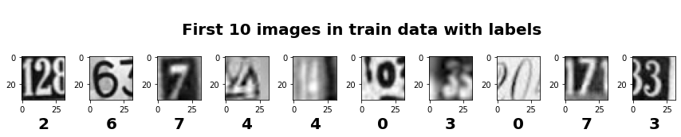

```python
# visualizing the first 10 images in train data with respective lables
%matplotlib inline
import matplotlib.pyplot as plt
plt.figure(figsize=(15, 1))

for cnt in range(10):
    ax=plt.subplot(1, 10, cnt+1)

    plt.imshow(X_train[cnt], cmap="gray")
    plt.xlabel(y_train[cnt], fontweight ="bold", fontsize=20)

plt.title("\nFirst 10 images in train data with labels                        \n", loc='right', fontweight ="bold", fontsize=20)
plt.show()
```

### C. Reshape all the images with appropriate shape update the data in same variable. [3 Marks]

```python
## Reshaping the data from 2D to 1D i.e 32 * 32 to 1024
image_vector_size = 32*32
X_train = X_train.reshape(X_train.shape[0], image_vector_size)
X_test = X_test.reshape(X_test.shape[0], image_vector_size)


print('Reshaped Training set', X_train.shape, y_train.shape)
print('Reshaped Test set', X_test.shape, y_test.shape)
```

```
Reshaped Training set (42000, 1024) (42000,)
Reshaped Test set (18000, 1024) (18000,)
```

### D. Normalise the images i.e. Normalise the pixel values. [2 Marks]

```python
# # normalize inputs from 0-255 to 0-1
X_train = X_train / 255.0
X_test = X_test / 255.0

print('Reshaped Training set', X_train.shape, y_train.shape)
print('Reshaped Test set', X_test.shape, y_test.shape)
```

```
Reshaped Training set (42000, 1024) (42000,)
Reshaped Test set (18000, 1024) (18000,)
```

```python
X_train
```

```
array([[0.12968785, 0.11866706, 0.10530196, ..., 0.19477727, 0.19942354,
        0.20799099],
       [0.34101608, 0.3414451 , 0.34656274, ..., 0.29498273, 0.30054745,
        0.31092745],
       [0.48284313, 0.49356118, 0.47872823, ..., 0.36837214, 0.41093138,
        0.44637334],
       ...,
       [0.6042902 , 0.61100274, 0.6149663 , ..., 0.52993256, 0.53592   ,
        0.5398412 ],
       [0.8137075 , 0.8176286 , 0.8353796 , ..., 0.83974785, 0.8319055 ,
        0.820142  ],
       [0.37285647, 0.37677765, 0.39246237, ..., 0.5414914 , 0.5509529 ,
        0.5509529 ]], dtype=float32)
```

```python
X_test
```

```
array([[0.15905097, 0.18349686, 0.19206432, ..., 0.43143883, 0.4360851 ,
        0.44780627],
       [0.45161137, 0.44769022, 0.44376904, ..., 0.1652502 , 0.18922432,
        0.20883021],
       [0.52256864, 0.52834475, 0.53456783, ..., 0.50266707, 0.5012169 ,
        0.5027937 ],
       ...,
       [0.6517247 , 0.64594865, 0.6385533 , ..., 0.6388313 , 0.6383843 ,
        0.63793725],
       [0.5395208 , 0.5360466 , 0.5286514 , ..., 0.56779647, 0.5599541 ,
        0.55603296],
       [0.11836078, 0.11836078, 0.11836078, ..., 0.13760431, 0.1359851 ,
        0.13368313]], dtype=float32)
```

### E. Transform Labels into format acceptable by Neural Network [2 Marks]

```python
from tensorflow.keras.utils import to_categorical
# one hot encode outputs
y_train = to_categorical(y_train)
y_test = to_categorical(y_test)
```

```python
y_train
```

```
array([[0., 0., 1., ..., 0., 0., 0.],
       [0., 0., 0., ..., 0., 0., 0.],
       [0., 0., 0., ..., 1., 0., 0.],
       ...,
       [0., 0., 0., ..., 1., 0., 0.],
       [1., 0., 0., ..., 0., 0., 0.],
       [0., 0., 0., ..., 0., 0., 0.]], dtype=float32)
```

```python
y_test
```

```
array([[0., 1., 0., ..., 0., 0., 0.],
       [0., 0., 0., ..., 1., 0., 0.],
       [0., 0., 1., ..., 0., 0., 0.],
       ...,
       [0., 0., 0., ..., 1., 0., 0.],
       [0., 0., 0., ..., 0., 0., 1.],
       [0., 0., 1., ..., 0., 0., 0.]], dtype=float32)
```

- All the entries in y_train and y_test are converted into array of 0s & 1s to represent the class.

### F. Print total Number of classes in the Dataset. [1 Marks]

```python
# no.of classes
num_class_train = y_train.shape[1]
print("The number of classes in train data:",num_class_train)
```

```
The number of classes in train data: 10
```

```python
# no.of classes
num_class_test = y_test.shape[1]
print("The number of classes in test data:",num_class_test)
```

```
The number of classes in test data: 10
```

## 3. Model Training & Evaluation using Neural Network [12 Marks]

### A. Design a Neural Network to train a classifier. [3 Marks]

```python
# create the nn classifier model for SVHN data
num_classes=num_class_train
def create_svhn_nn_model(lr,batch_size):
    np.random.seed(100)
    svhn_nn_model = Sequential()

    # The Input Layer :
    svhn_nn_model.add(Dense(256,input_dim = X_train.shape[1], activation='relu'))

    # The Hidden Layers :
    svhn_nn_model.add(Dense(128,activation='relu'))
    svhn_nn_model.add(Dense(64,activation='relu'))
    svhn_nn_model.add(Dense(32,activation='relu'))

    # The Output Layer :
    svhn_nn_model.add(Dense(num_classes,activation='softmax'))

    # Compile the network :
    optimizer = tf.keras.optimizers.Adam(learning_rate=lr)
    svhn_nn_model.compile(loss='categorical_crossentropy', optimizer=optimizer, metrics=['accuracy'])
    svhn_nn_model.summary()
    return svhn_nn_model
```

### B. Train the classifier using previously designed Architecture (Use best suitable parameters). [3 Marks]

```python
# Best suitable parameters for this model can be
lr=0.001
batch_size=300
EPOCH=100
```

```python
# Train the NN classifier model for SVHN data
svhn_nn_model = create_svhn_nn_model(lr,batch_size)
svhn_model = svhn_nn_model.fit(X_train, y_train, validation_data=(X_test, y_test), epochs=EPOCH, batch_size=batch_size, verbose=2)
```

```
Model: "sequential_3"
_________________________________________________________________
 Layer (type)                Output Shape              Param #
=================================================================
 dense_15 (Dense)            (None, 256)               262400

 dense_16 (Dense)            (None, 128)               32896

 dense_17 (Dense)            (None, 64)                8256

 dense_18 (Dense)            (None, 32)                2080

 dense_19 (Dense)            (None, 10)                330

=================================================================
Total params: 305,962
Trainable params: 305,962
Non-trainable params: 0
_________________________________________________________________
140/140 - 4s - loss: 2.2879 - accuracy: 0.1230 - val_loss: 2.2689 - val_accuracy: 0.1348 - 4s/epoch - 31ms/step
140/140 - 3s - loss: 2.1223 - accuracy: 0.2180 - val_loss: 1.9606 - val_accuracy: 0.2822 - 3s/epoch - 18ms/step
140/140 - 3s - loss: 1.7298 - accuracy: 0.3973 - val_loss: 1.5399 - val_accuracy: 0.4784 - 3s/epoch - 18ms/step
140/140 - 3s - loss: 1.4074 - accuracy: 0.5298 - val_loss: 1.3567 - val_accuracy: 0.5404 - 3s/epoch - 20ms/step
140/140 - 3s - loss: 1.2695 - accuracy: 0.5849 - val_loss: 1.2506 - val_accuracy: 0.5893 - 3s/epoch - 19ms/step
140/140 - 3s - loss: 1.1871 - accuracy: 0.6200 - val_loss: 1.1126 - val_accuracy: 0.6531 - 3s/epoch - 18ms/step
140/140 - 3s - loss: 1.1164 - accuracy: 0.6498 - val_loss: 1.0696 - val_accuracy: 0.6708 - 3s/epoch - 18ms/step
140/140 - 3s - loss: 1.0505 - accuracy: 0.6727 - val_loss: 1.0348 - val_accuracy: 0.6846 - 3s/epoch - 19ms/step
140/140 - 3s - loss: 1.0108 - accuracy: 0.6864 - val_loss: 1.0051 - val_accuracy: 0.6947 - 3s/epoch - 19ms/step
140/140 - 3s - loss: 0.9760 - accuracy: 0.6982 - val_loss: 1.0068 - val_accuracy: 0.6887 - 3s/epoch - 18ms/step
140/140 - 3s - loss: 0.9450 - accuracy: 0.7081 - val_loss: 0.9440 - val_accuracy: 0.7112 - 3s/epoch - 19ms/step
140/140 - 2s - loss: 0.9134 - accuracy: 0.7181 - val_loss: 0.9113 - val_accuracy: 0.7261 - 2s/epoch - 18ms/step
140/140 - 3s - loss: 0.8952 - accuracy: 0.7220 - val_loss: 1.0036 - val_accuracy: 0.6802 - 3s/epoch - 23ms/step
140/140 - 3s - loss: 0.8683 - accuracy: 0.7310 - val_loss: 0.9093 - val_accuracy: 0.7226 - 3s/epoch - 22ms/step
140/140 - 3s - loss: 0.8358 - accuracy: 0.7428 - val_loss: 0.8428 - val_accuracy: 0.7443 - 3s/epoch - 21ms/step
140/140 - 3s - loss: 0.8124 - accuracy: 0.7503 - val_loss: 0.8864 - val_accuracy: 0.7304 - 3s/epoch - 22ms/step
140/140 - 3s - loss: 0.7907 - accuracy: 0.7567 - val_loss: 0.8366 - val_accuracy: 0.7479 - 3s/epoch - 20ms/step
140/140 - 3s - loss: 0.7663 - accuracy: 0.7629 - val_loss: 0.8419 - val_accuracy: 0.7486 - 3s/epoch - 20ms/step
140/140 - 3s - loss: 0.7540 - accuracy: 0.7689 - val_loss: 0.8368 - val_accuracy: 0.7464 - 3s/epoch - 19ms/step
140/140 - 3s - loss: 0.7453 - accuracy: 0.7707 - val_loss: 0.7764 - val_accuracy: 0.7662 - 3s/epoch - 19ms/step
140/140 - 3s - loss: 0.7186 - accuracy: 0.7787 - val_loss: 0.7900 - val_accuracy: 0.7621 - 3s/epoch - 20ms/step
```

[output cut: 64 more lines]

```
140/140 - 3s - loss: 0.3582 - accuracy: 0.8862 - val_loss: 0.6555 - val_accuracy: 0.8227 - 3s/epoch - 19ms/step
140/140 - 3s - loss: 0.3472 - accuracy: 0.8902 - val_loss: 0.6313 - val_accuracy: 0.8276 - 3s/epoch - 19ms/step
140/140 - 3s - loss: 0.3558 - accuracy: 0.8870 - val_loss: 0.6494 - val_accuracy: 0.8264 - 3s/epoch - 19ms/step
140/140 - 3s - loss: 0.3455 - accuracy: 0.8907 - val_loss: 0.6752 - val_accuracy: 0.8194 - 3s/epoch - 19ms/step
140/140 - 3s - loss: 0.3666 - accuracy: 0.8817 - val_loss: 0.6766 - val_accuracy: 0.8189 - 3s/epoch - 18ms/step
140/140 - 3s - loss: 0.3471 - accuracy: 0.8895 - val_loss: 0.6748 - val_accuracy: 0.8171 - 3s/epoch - 19ms/step
140/140 - 3s - loss: 0.3510 - accuracy: 0.8878 - val_loss: 0.6733 - val_accuracy: 0.8232 - 3s/epoch - 18ms/step
140/140 - 3s - loss: 0.3388 - accuracy: 0.8912 - val_loss: 0.6856 - val_accuracy: 0.8145 - 3s/epoch - 18ms/step
140/140 - 3s - loss: 0.3340 - accuracy: 0.8933 - val_loss: 0.6721 - val_accuracy: 0.8204 - 3s/epoch - 18ms/step
140/140 - 3s - loss: 0.3403 - accuracy: 0.8915 - val_loss: 0.6864 - val_accuracy: 0.8194 - 3s/epoch - 18ms/step
140/140 - 3s - loss: 0.3398 - accuracy: 0.8904 - val_loss: 0.6822 - val_accuracy: 0.8176 - 3s/epoch - 18ms/step
140/140 - 3s - loss: 0.3346 - accuracy: 0.8924 - val_loss: 0.7067 - val_accuracy: 0.8122 - 3s/epoch - 18ms/step
140/140 - 3s - loss: 0.3321 - accuracy: 0.8946 - val_loss: 0.6615 - val_accuracy: 0.8273 - 3s/epoch - 18ms/step
140/140 - 2s - loss: 0.3404 - accuracy: 0.8908 - val_loss: 0.6824 - val_accuracy: 0.8196 - 2s/epoch - 17ms/step
140/140 - 2s - loss: 0.3154 - accuracy: 0.8991 - val_loss: 0.6696 - val_accuracy: 0.8269 - 2s/epoch - 18ms/step
```

### C. Evaluate performance of the model with appropriate metrics. [2 Marks]

```python
svhn_model_results = svhn_nn_model.evaluate(X_test, y_test)
```

```python
print('Test loss: ', svhn_model_results[0])
print('Test accuracy: ', svhn_model_results[1])
```

```
Test loss:  0.6695700287818909
Test accuracy:  0.8269444704055786
```

#### The model has predicted accurately for 82.69% of the test population. Loss is calculated as 66.95%

### D. Plot the training loss, validation loss vs number of epochs and training accuracy, validation accuracy vs number of epochs plot and write your observations on the same. [4 Marks]

#### Plotting training loss, Validation loss Vs number of epochs

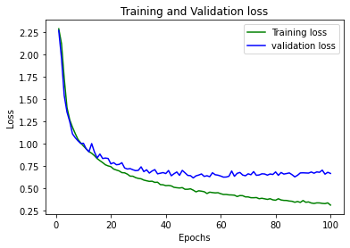

```python
loss_train = svhn_model.history['loss']
loss_val = svhn_model.history['val_loss']
epochs = range(1,EPOCH+1)
plt.plot(epochs, loss_train, 'g', label='Training loss')
plt.plot(epochs, loss_val, 'b', label='validation loss')
plt.title('Training and Validation loss')
plt.xlabel('Epochs')
plt.ylabel('Loss')
plt.legend()
plt.show()
```

#### Plotting training accuracy, Validation accuracy Vs number of epochs

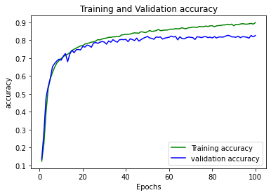

```python
Acc_train = svhn_model.history['accuracy']
Acc_val = svhn_model.history['val_accuracy']
epochs = range(1,EPOCH+1)
plt.plot(epochs, Acc_train, 'g', label='Training accuracy')
plt.plot(epochs, Acc_val, 'b', label='validation accuracy')
plt.title('Training and Validation accuracy')
plt.xlabel('Epochs')
plt.ylabel('accuracy')
plt.legend()
plt.show()
```

#### Observation:

The Street View House Number (SVHN) dataset has 10 classes representing the image data for digits 0-9.

Neural Network classifier model with 1 input layer, 3 hidden layers and 1 output layer was built using relu activation function.

With the best suitable parameters of Learning Rate: 0.001, Batch size: 300 , Epochs :100 the NN classifier model gave the below results:

- Accuracy in training dataset = 89.91%
- Accuracy in test dataset = 82.69%
- Loss in training dataset = 31.54%
- Loss in test dataset = 66.96%

#### Conclusion: Model Training accuracy of 89.91% and Test accuracy of 82.69% is the optimized model that was built for this SVHN dataset.